# Travel Package Purchase Prediction

## Model Building

### Model Evaluation Criterion

**Model can make two kinds of wrong predictions:**

1. Predicting that the customer will purchase a Travel Package when they don"t. - False Positive.
2. Predicting that the customer will not purchase a Travel Package when they do. - False Negative.

**The Travel company"s objectives are:**

1. Make Marketing Expenditure more efficient and focused on the customers that would actually purchase the product.
2. Predict and Identify all potential customers who will purchase the newly introduced travel package.

**Metric for Optimization:**

For the above objectives, its important that both False positive and False negative values are low. Hence we would want the F1-Score to be maximized. The greater the F1-Score, greater the chances of predicting both classes correctly.

**We will build following models, tune them and compare the outcome of all the models:**

1. Decision Tree model.
2. Bagging Classifier.
3. Random Forest Classifier.
4. ADABoost.
5. GradientBoost.
6. XG Boost.
7. Stacking Classifier.

### Split the data in Train and Test Sets

- Since I have a significant imbalance in the distribution of the target classes, I will use stratified sampling to ensure that relative class frequencies are approximately preserved in train and test sets.
- For that I will use the `stratify` parameter in the train_test_split function.
- Since customer interaction data will not be available for potential customers who will purchase newly introduced travel package ,so I will drop those variables from our data for modelling.

```python
data_travel.info()
```

```
<class 'pandas.core.frame.DataFrame'>
Int64Index: 4878 entries, 0 to 4887
Data columns (total 22 columns):
 #   Column                    Non-Null Count  Dtype
---  ------                    --------------  -----
 0   CustomerID                4878 non-null   int64
 1   ProdTaken                 4878 non-null   category
 2   Age                       4878 non-null   float64
 3   TypeofContact             4878 non-null   category
 4   CityTier                  4878 non-null   category
 5   DurationOfPitch           4878 non-null   float64
 6   Occupation                4878 non-null   category
 7   Gender                    4878 non-null   category
 8   NumberOfPersonVisiting    4878 non-null   int64
 9   NumberOfFollowups         4878 non-null   float64
 10  ProductPitched            4878 non-null   category
 11  PreferredPropertyStar     4878 non-null   float64
 12  MaritalStatus             4878 non-null   category
 13  NumberOfTrips             4878 non-null   float64
 14  Passport                  4878 non-null   category
 15  PitchSatisfactionScore    4878 non-null   int64
 16  OwnCar                    4878 non-null   category
 17  NumberOfChildrenVisiting  4878 non-null   float64
 18  Designation               4878 non-null   category
 19  MonthlyIncome             4878 non-null   float64
 20  Agebin                    4878 non-null   category
 21  Incomebin                 4878 non-null   category
dtypes: category(12), float64(7), int64(3)
memory usage: 478.5 KB
```

**Customer Interaction data is not relevant for our analysis and we will ignore. Also CustomerID column is not required**

```python
# split the columns in Dependent and Independent Set
# split the columns in Dependent and Independent Set
X= data_travel.drop(['CustomerID','ProdTaken','PitchSatisfactionScore','ProductPitched','NumberOfFollowups','DurationOfPitch','Agebin','Incomebin'],axis=1)
y= data_travel['ProdTaken']
```

#### Create dummy variables for the categorical columns

```python
# use get_dummies function to convert the categorical columns
X = pd.get_dummies(X, drop_first=True)
```

### Split the data in Training and Testing Sets

```python
# splitting data into training and test set, use stratify to maintain the original distribution of Dependent variable as of original set
X_train,X_test, y_train, y_test =train_test_split(X,y, test_size=0.3, random_state=25,stratify=y)

# creating a list of column names
feature_names = X_train.columns.to_list()
```

```python
# calculate different metric scores of the model - Accuracy, Recall, F1 and Precision
def get_metrics_score(model,flag=True):
    """
    model : classifier to predict values of X

    """
    # defining an empty list to store train and test results
    score_list=[]

    # predicting on train and tests
    pred_train = model.predict(X_train)
    pred_test = model.predict(X_test)

    # accuracy of the model
    train_acc = model.score(X_train,y_train)
    test_acc = model.score(X_test,y_test)

    # recall of the model
    train_recall = metrics.recall_score(y_train,pred_train)
    test_recall = metrics.recall_score(y_test,pred_test)

    # precision of the model
    train_precision = metrics.precision_score(y_train,pred_train)
    test_precision = metrics.precision_score(y_test,pred_test)

    # f1_score of the model
    train_f1 = metrics.f1_score(y_train,pred_train)
    test_f1 = metrics.f1_score(y_test,pred_test)

    # populate the score_list
    score_list.extend((train_acc,test_acc,train_recall,test_recall,train_precision,test_precision,train_f1,test_f1))

    # If the flag is set to True then only the following print statements will be dispayed. The default value is set to True.
    if flag == True:
        print("Accuracy on training set : ",train_acc)
        print("Accuracy on test set : ",test_acc)
        print("Recall on training set : ",train_recall)
        print("Recall on test set : ",test_recall)
        print("Precision on training set : ",train_precision)
        print("Precision on test set : ",test_precision)
        print("F1 on training set : ",train_f1)
        print("F1 on test set : ",test_f1)
    return score_list # returning the list with train and test scores
```

### Confusion Matrix

```python
def draw_matrix(model, predictors, target):
    """
    To plot the confusion_matrix with percentages

    model: classifier
    predictors: independent variables
    target: dependent variable
    """
    y_pred = model.predict(predictors)
    cm = confusion_matrix(target, y_pred)
    labels = np.asarray(
        [
            ["{0:0.0f}".format(item) + "\n{0:.2%}".format(item / cm.flatten().sum())]
            for item in cm.flatten()
        ]
    ).reshape(2, 2)

    plt.figure(figsize=(6, 4))
    sns.heatmap(cm, annot=labels, fmt="")
    plt.ylabel("True label")
    plt.xlabel("Predicted label")
    plt.show()
```

```python
# splitting data into training and test set, use stratify to maintain the original distribution of Dependent variable as of original set
X_train,X_test, y_train, y_test =train_test_split(X,y, test_size=0.3, random_state=25,stratify=y)

# creating a list of column names
feature_names = X_train.columns.to_list()
```

#### Check the split of target variable ProdTaken

```python
print("Original ProdTaken True Values    : {0} ({1:0.2f}%)".format(len(data_travel.loc[data_travel["ProdTaken"] == 1]), (len(data_travel.loc[data_travel["ProdTaken"] == 1])/len(data_travel.index)) * 100))
print("Original ProdTaken False Values   : {0} ({1:0.2f}%)".format(len(data_travel.loc[data_travel["ProdTaken"] == 0]), (len(data_travel.loc[data_travel["ProdTaken"] == 0])/len(data_travel.index)) * 100))
print("")
print("Training ProdTaken True Values    : {0} ({1:0.2f}%)".format(len(y_train[y_train[:] == 1]), (len(y_train[y_train[:] == 1])/len(y_train)) * 100))
print("Training ProdTaken False Values   : {0} ({1:0.2f}%)".format(len(y_train[y_train[:] == 0]), (len(y_train[y_train[:] == 0])/len(y_train)) * 100))
print("")
print("Test ProdTaken True Values        : {0} ({1:0.2f}%)".format(len(y_test[y_test[:] == 1]), (len(y_test[y_test[:] == 1])/len(y_test)) * 100))
print("Test ProdTaken False Values       : {0} ({1:0.2f}%)".format(len(y_test[y_test[:] == 0]), (len(y_test[y_test[:] == 0])/len(y_test)) * 100))
```

```
Original ProdTaken True Values    : 918 (18.82%)
Original ProdTaken False Values   : 3960 (81.18%)

Training ProdTaken True Values    : 642 (18.80%)
Training ProdTaken False Values   : 2772 (81.20%)

Test ProdTaken True Values        : 276 (18.85%)
Test ProdTaken False Values       : 1188 (81.15%)
```

## Model building - Bagging

### Decision Tree Classifier

```python
# DecistionTreeClassifier with gini and class_weight for appropriate importance
dtc = DecisionTreeClassifier(criterion="gini",class_weight={0:0.15,1:0.85},random_state=1)

# fit the model on training dataset
dtc.fit(X_train, y_train)
```

```
DecisionTreeClassifier(class_weight={0: 0.15, 1: 0.85}, random_state=1)
```

#### I am going to Check the scores

```python
# check the scores on Training and Testing Datasets
dtc_score = get_metrics_score(dtc)
```

```
Accuracy on training set :  1.0
Accuracy on test set :  0.8866120218579235
Recall on training set :  1.0
Recall on test set :  0.6811594202898551
Precision on training set :  1.0
Precision on test set :  0.706766917293233
F1 on training set :  1.0
F1 on test set :  0.6937269372693726
```

### Visualied the tree

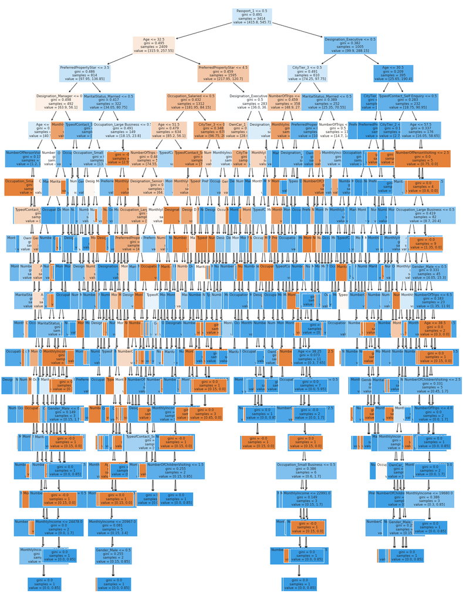

```python
# plot the decision tree
plt.figure(figsize=(20, 30))
out = tree.plot_tree(
    dtc,
    feature_names=feature_names,
    filled=True,
    fontsize=9,
    node_ids=False,
    class_names=None,
)
# below code will add arrows to the decision tree split if they are missing
for o in out:
    arrow = o.arrow_patch
    if arrow is not None:
        arrow.set_edgecolor("black")
        arrow.set_linewidth(1)

plt.show()
```

#### confusion matrix

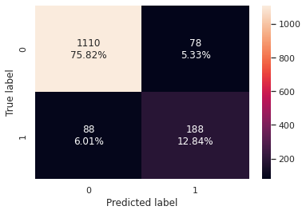

```python
# use draw_matrix function
draw_matrix(dtc, X_test, y_test)
```

#### Feature important variables

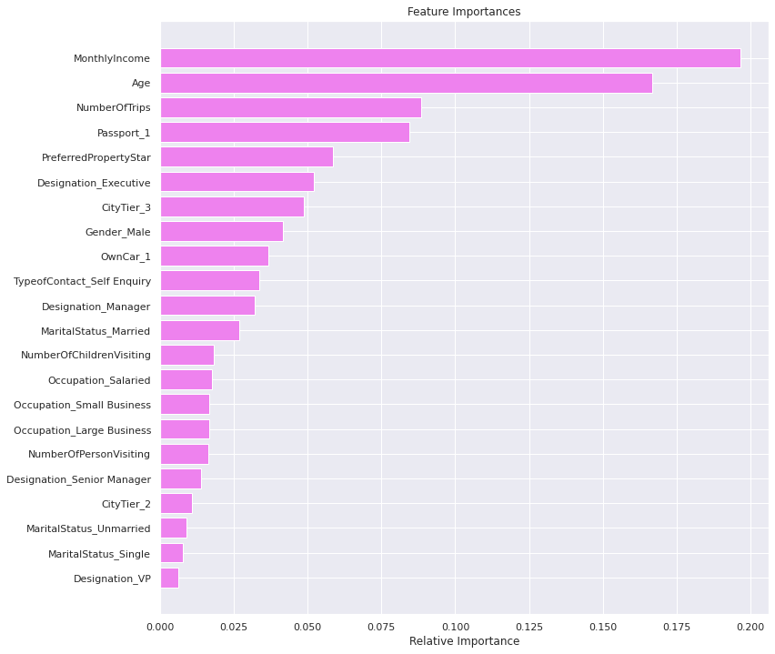

```python
# plot a horizontal bar graph
importances = dtc.feature_importances_
indices = np.argsort(importances)

plt.figure(figsize=(12, 12))
plt.title("Feature Importances")
plt.barh(range(len(indices)), importances[indices], color="violet", align="center")
plt.yticks(range(len(indices)), [feature_names[i] for i in indices])
plt.xlabel("Relative Importance")
plt.show()
```

**Observations:**

## Model performance improvement - Bagging

### Hypertuning of Decision Tree Classifier

```python
# choose the type of classifier.
dtc1 = DecisionTreeClassifier(random_state=1,class_weight = {0:.15,1:.85}) #adding classweights

# defining the Hyperparameters
parameters = {"max_depth": np.arange(10,60,10),
            "criterion": ["gini","entropy"],
            "min_samples_leaf": [ 2, 5, 7, 10],
            "max_leaf_nodes" : [3, 5, 10,15],}

# type of scoring used to compare parameter combinations
scorer = metrics.make_scorer(metrics.f1_score)

# run the grid search with the above parameters
grid_obj = GridSearchCV(dtc1, parameters, scoring=scorer,cv=5)
grid_obj = grid_obj.fit(X_train, y_train)

# set to the best combination of parameters
dtcht = grid_obj.best_estimator_

# fit the best algorithm to the data.
dtcht.fit(X_train, y_train)
```

```
DecisionTreeClassifier(class_weight={0: 0.15, 1: 0.85}, max_depth=10,
                       max_leaf_nodes=15, min_samples_leaf=5, random_state=1)
```

#### Visualise the Tree

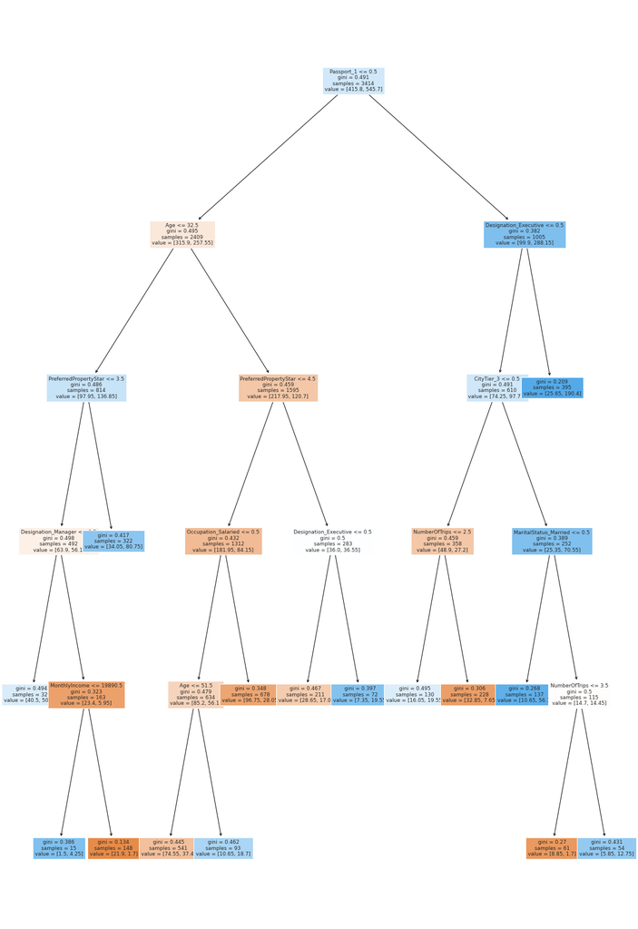

```python
# plot the decision tree
plt.figure(figsize=(20, 30))
out = tree.plot_tree(
    dtcht,
    feature_names=feature_names,
    filled=True,
    fontsize=9,
    node_ids=False,
    class_names=None,
)
# below code will add arrows to the decision tree split if they are missing
for o in out:
    arrow = o.arrow_patch
    if arrow is not None:
        arrow.set_edgecolor("black")
        arrow.set_linewidth(1)

plt.show()
```

#### Checking the scores

```python
# check the scores on Training and Testing Datasets
dtcht_scores = get_metrics_score(dtcht)
```

```
Accuracy on training set :  0.6704745166959578
Accuracy on test set :  0.6516393442622951
Recall on training set :  0.8286604361370716
Recall on test set :  0.7862318840579711
Precision on training set :  0.3438914027149321
Precision on test set :  0.3248502994011976
F1 on training set :  0.4860666971219735
F1 on test set :  0.4597457627118644
```

#### confusion matrix

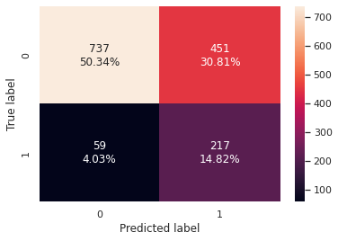

```python
# use draw_matrix function
draw_matrix(dtcht, X_test, y_test)
```

#### Feature important variables

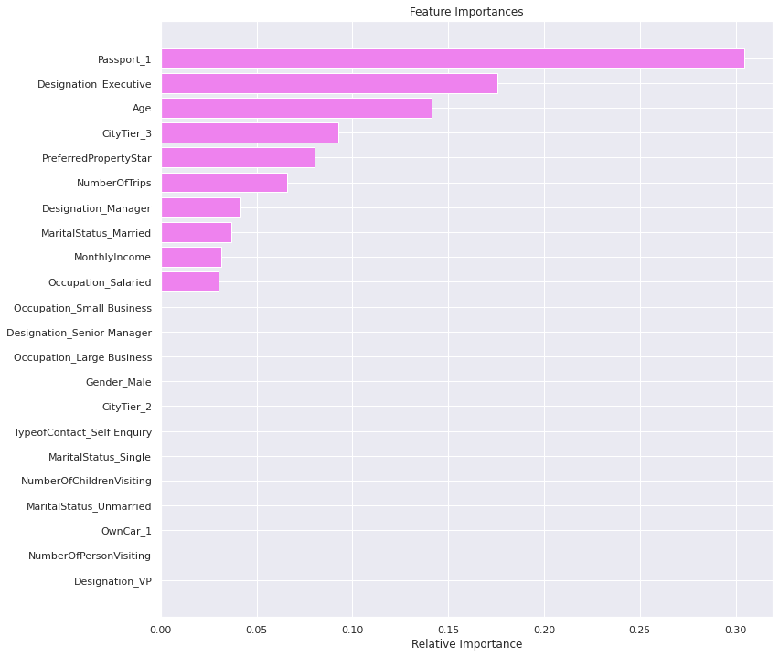

```python
# plot a horizontal bar graph
importances = dtcht.feature_importances_
indices = np.argsort(importances)

plt.figure(figsize=(12, 12))
plt.title("Feature Importances")
plt.barh(range(len(indices)), importances[indices], color="violet", align="center")
plt.yticks(range(len(indices)), [feature_names[i] for i in indices])
plt.xlabel("Relative Importance")
plt.show()
```

**Observations:**

### Bagging Classifier

```python
# baggingClassifier
bgc = BaggingClassifier(random_state=1)

# fit the model on training dataset
bgc.fit(X_train, y_train)
```

```
BaggingClassifier(random_state=1)
```

#### Checking the scores

```python
# check the scores on Training and Testing Datasets
bgc_score = get_metrics_score(bgc)
```

```
Accuracy on training set :  0.992091388400703
Accuracy on test set :  0.9009562841530054
Recall on training set :  0.9641744548286605
Recall on test set :  0.5652173913043478
Precision on training set :  0.9935794542536116
Precision on test set :  0.861878453038674
F1 on training set :  0.9786561264822136
F1 on test set :  0.6827133479212254
```

#### confusion matrix

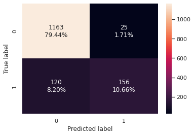

```python
# use draw_matrix function
draw_matrix(bgc, X_test, y_test)
```

**Observations:**

### Bagging Classifier with Logistic_Regression

```python
# BaggingClassifier with gini and class_weight for appropriate importance
bgclr = BaggingClassifier(base_estimator=LogisticRegression(solver="liblinear", random_state=1),random_state=1)

# fit the model on training set
bgclr.fit(X_train,y_train)
```

```
BaggingClassifier(base_estimator=LogisticRegression(random_state=1,
                                                    solver='liblinear'),
                  random_state=1)
```

```python
#### Check the scores
```

```python
# check the scores on Training and Testing Datasets
bgclr_score = get_metrics_score(bgclr)
```

```
Accuracy on training set :  0.81195079086116
Accuracy on test set :  0.8114754098360656
Recall on training set :  0.0
Recall on test set :  0.0
Precision on training set :  0.0
Precision on test set :  0.0
F1 on training set :  0.0
F1 on test set :  0.0
```

#### confusion matrix

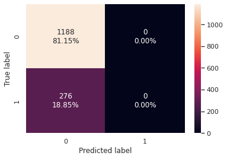

```python
# use draw_matrix function
draw_matrix(bgclr, X_test, y_test)
```

**Observations:**

1. Use the Logistic_Regression as base estimator does not fit for our analysis as it has reduced the f1_score to zero.
2. The model is not able to identify any true positives.
3. However the model is not over fitting, it also gives us the comparable accuracy on both training and testing sets.
4. Let us try Bagging Classifier with base_estimator as DecisionTreeClassifier.

### Bagging Classifier with Decision Tree

```python
# BaggingClassifier with gini and class_weight for appropriate importance
bgcdt = BaggingClassifier(base_estimator=DecisionTreeClassifier(criterion="gini",class_weight={0:0.15,1:0.85},random_state=1),random_state=1)

# fit the model on training set
bgcdt.fit(X_train,y_train)
```

```
BaggingClassifier(base_estimator=DecisionTreeClassifier(class_weight={0: 0.15,
                                                                      1: 0.85},
                                                        random_state=1),
                  random_state=1)
```

#### Checking the scores

```python
# check the scores on Training and Testing Datasets
bgcdt_score = get_metrics_score(bgcdt)
```

```
Accuracy on training set :  0.9912126537785588
Accuracy on test set :  0.8852459016393442
Recall on training set :  0.9548286604361371
Recall on test set :  0.4492753623188406
Precision on training set :  0.998371335504886
Precision on test set :  0.8857142857142857
F1 on training set :  0.9761146496815287
F1 on test set :  0.5961538461538461
```

#### confusion matrix

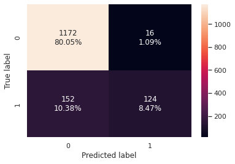

```python
# use draw_matrix function
draw_matrix(bgcdt, X_test, y_test)
```

**Observations:**

1. The model with weighted decision tree hasn"t improved the metrics.
2. The true positive"s identified are even lesser.

### Hypertuned Bagging Classifier

```python
# set the parameters
parameters = {
              "n_estimators":np.arange(10,60,10),
              "max_features": [0.7,0.8,0.9],
              "max_samples": [0.7,0.8,0.9],
             }

# assigning Bootstrap = True to select features with Replacement
bgc1 = BaggingClassifier(random_state=1,bootstrap=True)

# type of scoring used to compare parameter combinations
scorer = metrics.make_scorer(metrics.f1_score)

# run the grid search
grid_obj = GridSearchCV(bgc1, parameters, scoring=scorer,cv=5)
grid_obj = grid_obj.fit(X_train, y_train)

# set the clf to the best combination of parameters
bgcht = grid_obj.best_estimator_

# fit the best algorithm to the data.
bgcht.fit(X_train, y_train)
```

```
BaggingClassifier(max_features=0.9, max_samples=0.9, n_estimators=50,
                  random_state=1)
```

#### Checking the scores

```python
# check the scores on Training and Testing Datasets
bgcht_score = get_metrics_score(bgcht)
```

```
Accuracy on training set :  0.9991212653778558
Accuracy on test set :  0.9098360655737705
Recall on training set :  0.9953271028037384
Recall on test set :  0.5978260869565217
Precision on training set :  1.0
Precision on test set :  0.8870967741935484
F1 on training set :  0.9976580796252927
F1 on test set :  0.7142857142857144
```

#### confusion matrix

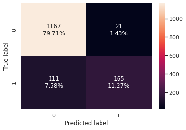

```python
# use draw_matrix function
draw_matrix(bgcht, X_test, y_test)
```

**Observations:**

1. We see that the Train and Test Accuracy and F1Score Performance has increased after tuning compared to the previous models.
2. The Model is over-fitting as the difference between Train and Test scores are very high.
3. The Model seems to identify all non-buyers better as the False Positive value is low.